# Nu-Way Homes

## Properties sold in Northampton

[figure not shown]

### [38 Stoddard St](https://www.zillow.com/homedetails/38-Stoddard-St-Northampton-MA-01060/2084411191_zpid/)

- ? bd | ? ba | ? sqft
- Paid $185,000 for lot on August 22nd, 2018
- Sold for **$610,500** on March 28th, 2019

### [181 Round Hill Rd](https://www.zillow.com/homes/181-round-hill-rd_rb/309911123_zpid/)

- 4 bd | 3 ba | 2,453 sqft
- Sold for **$785,000** on July 31st, 2020

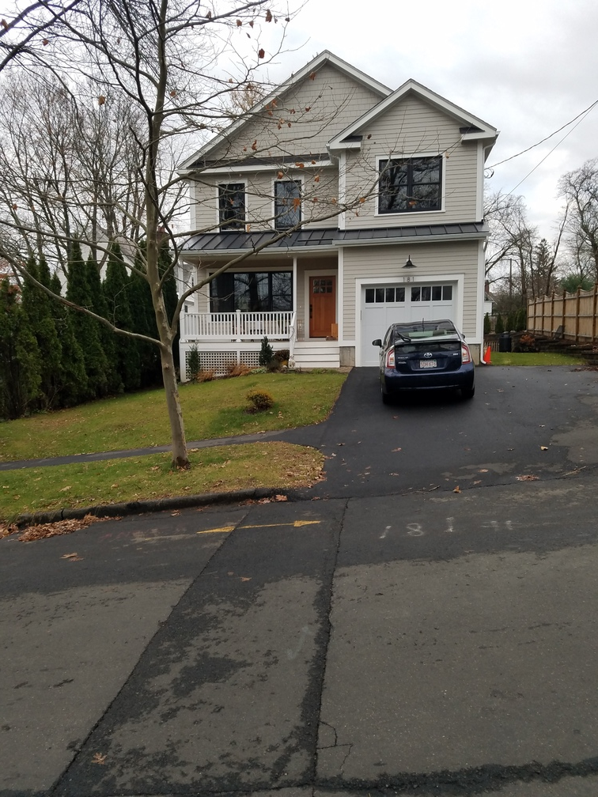

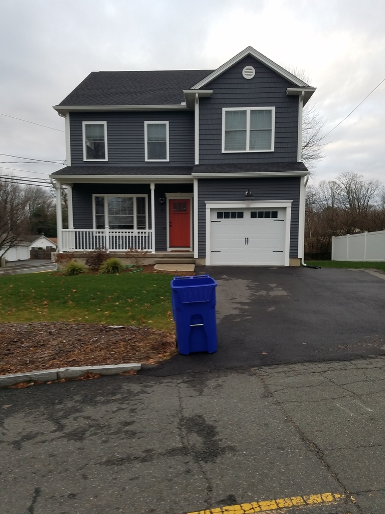

### [4 Rust Ave / 37 Chapel St](https://www.zillow.com/homedetails/4-Rust-Ave-Northampton-MA-01060/2082525101_zpid/)

- 3 bd | 3 ba | 1,717 sqft
- Bought condemned house for $50,000 1/2/19
- Demolished existing house and built new 1,717 sq. ft house.
- Sold for **$459,000** on 12/19/19

### [36 Landy Ave](https://www.zillow.com/homes/36-landy-ave_rb/123115388_zpid/)

- Bought infill lot for $65,000 (adjacent house at 40 Landy Ave. was purchased by a different individual)
- Lot size 8,072 sq. ft.
- House built in 2017, 3 bd, 2.5 ba, 1,722 sq. ft.
- Sold for $420,000 Nov. 6th, 2017.
- [Current estimate on Zillow](https://www.zillow.com/homes/36-landy-ave_rb/123115388_zpid/): **$495,496**

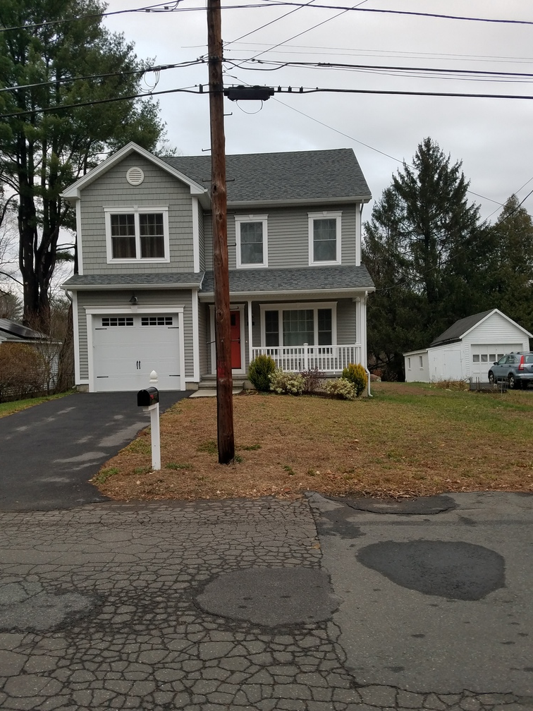

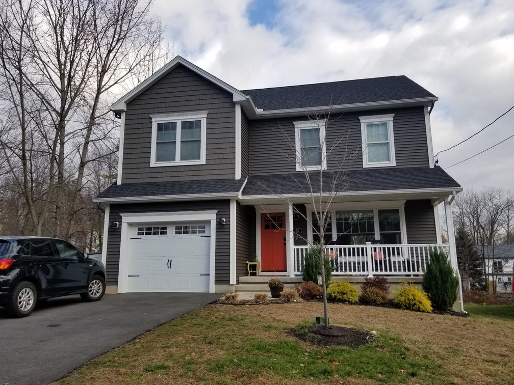

### [12/14 Winslow Ave](https://www.zillow.com/homedetails/12-Winslow-Ave-Northampton-MA-01062/309911113_zpid/)

- Purchased house & infill lot for $337,000
- Sold 14 Winslow Ave. house for $275,000
- Sold house he built on 12 Winslow Ave. for **$523,000** May 14th, 2020

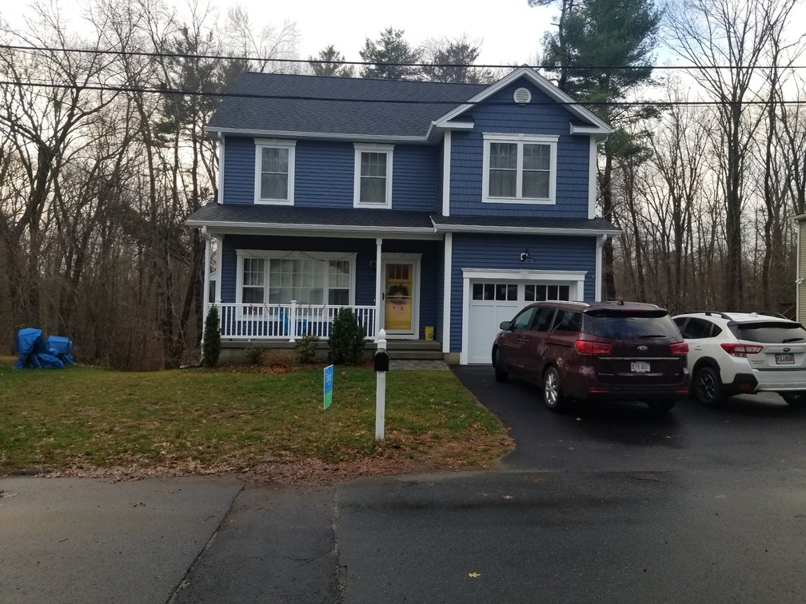

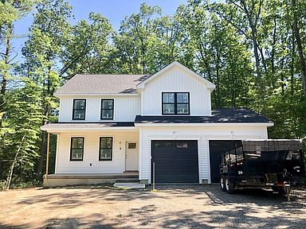

### [59 Ice Pond Dr](https://www.zillow.com/homes/59-Ice-Pond-Dr-Northampton,-MA,-01062_rb/123892070_zpid/)

- 3 bd | 3 ba | 1,923 sqft
- Bought lot for $115,000 on October 11th, 2019
- Built house and sold for **$579,000** on October 15th, 2020

## Map

[interactive chart not shown]

Nu-Way properties in Northampton

## Mass Land Records data

| date | Type | Name/ Corporation | Book | Page | Type Desc. | address | Town |
| --- | --- | --- | --- | --- | --- | --- | --- |
| 2016-11-30 | GT | NU-WAY HOMES INC | 12482 | 305 | DEED | LANDY AVE | NORTHAMPTON |
| 2016-12-16 | GR | NU-WAY HOMES INC | 12499 | 263 | MORTGAGE | LANDY AVE | NORTHAMPTON |
| 2016-12-16 | GT | HANDZEL JOHN S | 12499 | 263 | MORTGAGE | LANDY AVE | NORTHAMPTON |
| 2017-11-06 | GR | NU-WAY HOLMES INC | 12797 | 260 | MUNICIPAL LIEN CERTIFICATE | 36 LANDY AVE | NORTHAMPTON |
| 2017-11-06 | GT | HANDZEL JOHN M | 12797 | 265 | PARTIAL RELEASE | 36 LANDY AVE | NORTHAMPTON |
| 2017-11-06 | GR | HANDZEL JOHN S | 12797 | 265 | PARTIAL RELEASE | 36 LANDY AVE | NORTHAMPTON |
| 2018-05-21 | GR | NU-WAY HOMES INC | 12959 | 71 | MUNICIPAL LIEN CERTIFICATE | 19 LEXINGTON AVE | NORTHAMPTON |
| 2018-08-22 | GT | NU-WAY HOMES INC | 13057 | 239 | DEED | 32A STODDARD ST | NORTHAMPTON |
| 2018-11-02 | GR | NU-WAY HOMES INC | 13119 | 124 | MUNICIPAL LIEN CERTIFICATE | 23 LEXINGTON AVE | NORTHAMPTON |
| 2018-11-02 | GR | NU-WAY HOMES INC | 13119 | 127 | DEED | 23 LEXINGTON AVE | NORTHAMPTON |

[output cut: 26 more lines]

## References

- [Google doc](https://docs.google.com/document/d/15OIC5T3rKYy7OcPmK5tzOjbN8xw05lpU/)
- [Mass Land Records](https://www.masslandrecords.com/Hampshire/default.aspx)